# Advanced Lane Detection

### Steps of the Advanced Lane Detection Project Pipeline at a high level are -

1. Camera Calibration
2. Distortion Correction
3. Color and Gradient Threshold
4. Perspective Transform
5. Detect Lane Lines
6. Fit 2nd order polynomial
7. Search Windows on Lane Boundaries
8. Output Visual Display of Lane Boundaries and Numerical Estimation of Lane Curvature and Vehicle Position

```python
import pickle
import cv2
import numpy as np
import matplotlib.pyplot as plt
import matplotlib.image as mpimg
import glob, os
from moviepy.editor import VideoFileClip
from IPython.display import HTML

GENERATE_OUT_FIGURES = False
```

## Step 1: Camera Calibration Stage

Using the cv2.findChessboardCorners to estimate camera distortion components from the 20 calibration images

```python
def CameraCalibration():

    file_path = glob.glob("camera_cal\*.jpg")

    objpoints = []  # 3D points
    imgpoints = []  # 2D points
    nx = 9
    ny = 6

    for ii in range(len(file_path)):

        file = file_path[ii]
        im = plt.imread(file)
        objp = np.zeros((nx*ny,3),np.float32)
        objp[:,:2] = np.mgrid[0:nx,0:ny].T.reshape(-1,2)
        gray = cv2.cvtColor(im, cv2.COLOR_RGB2GRAY)
        ret, corners = cv2.findChessboardCorners(gray, (nx,ny), None)

        if ret == True:
            imgpoints.append(corners)
            objpoints.append(objp)

    ret, mtx, dist, rvec, tvec = cv2.calibrateCamera(objpoints, imgpoints, gray.shape[::-1], None, None)
    return mtx, dist
```

## Step 2: Camera Distotion Correction

Check how the camera cv2.undistort function works on the calibration camera images the undistort matrix derived from the calibration function to be used in test images and video

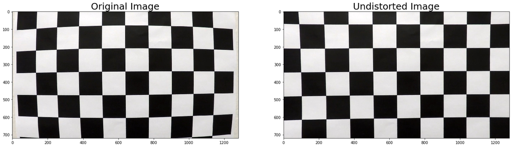

```python
file_path = glob.glob("camera_cal\*.jpg")
file = file_path[0]

img = plt.imread(file)

mtx, dist = CameraCalibration()

undist = cv2.undistort(img, mtx, dist, None, mtx)

fig, axs= plt.subplots(1,2, figsize=(24,9))
axs = axs.ravel()
axs[0].imshow(img)
axs[0].set_title('Original Image', fontsize=25)
axs[1].imshow(undist)
axs[1].set_title('Undistorted Image', fontsize=25)
```

## Step 4: Perspective Transformation

Using the straight_lines2.jpg image to select source and destination points to generate the perspective transformation across which the test images to be transformed

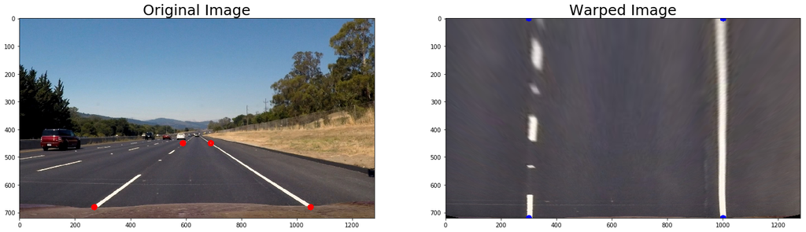

```python
def PerspectiveTransform(img, src, dst):

    img_size = (img.shape[1], img.shape[0])

    M = cv2.getPerspectiveTransform(src, dst)
    Minv = cv2.getPerspectiveTransform(dst, src)

    warped = cv2.warpPerspective(img, M, img_size, flags=cv2.INTER_LINEAR)
    unwarped = cv2.warpPerspective(warped, Minv, (warped.shape[1], warped.shape[0]), flags=cv2.INTER_LINEAR)

    return warped, M, Minv


img = plt.imread('test_images\straight_lines2.jpg')
src = np.float32([[270,680], [590,450], [690,450], [1050,680]])
#src = np.float32([[220,680], [520,475], [770,475], [1070,680]])
dst = np.float32([[300, 720], [300, 0], [1000,0], [1000,720]])

warped_img, M, Minv = PerspectiveTransform(img, src, dst)

for ii in range(4):
    cv2.circle(img, (src[ii][0],src[ii][1]), radius = 6, color = (255,0,0),thickness = 10)
    cv2.circle(warped_img, (dst[ii][0],dst[ii][1]), radius = 6, color = (0,0,255),thickness = 10)

fig, axs= plt.subplots(1,2, figsize=(24,9))
axs = axs.ravel()
axs[0].imshow(img)
axs[0].set_title('Original Image', fontsize=25)
axs[1].imshow(warped_img)
axs[1].set_title('Warped Image', fontsize=25)
```

### Step 3: Gradient and Color Binary Thresholding

Sobel transformation to identify the lanes by Sobel transformation along x axis, magnitude and direction, and combining the gradient binary image with the S-channel colorspace.

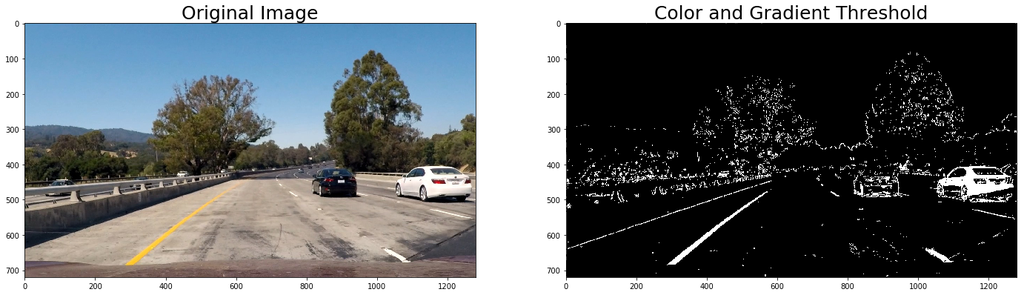

```python
def abs_sobel_thresh(img, orient='x', thresh_min=20, thresh_max=100):

    gray = cv2.cvtColor(img, cv2.COLOR_RGB2GRAY)
    if orient == 'x':
        abs_sobel = np.absolute(cv2.Sobel(gray, cv2.CV_64F, 1, 0))
    if orient == 'y':
        abs_sobel = np.absolute(cv2.Sobel(gray, cv2.CV_64F, 0, 1))
    scaled_sobel = np.uint8(255*abs_sobel/np.max(abs_sobel))
    binary_output = np.zeros_like(scaled_sobel)
    binary_output[(scaled_sobel >= thresh_min) & (scaled_sobel <= thresh_max)] = 1

    return binary_output

def dir_threshold(img, sobel_kernel=3, thresh=(0, np.pi/2)):

    gray = cv2.cvtColor(img, cv2.COLOR_RGB2GRAY)
    sobelx = cv2.Sobel(gray, cv2.CV_64F, 1, 0, ksize=sobel_kernel)
    sobely = cv2.Sobel(gray, cv2.CV_64F, 0, 1, ksize=sobel_kernel)
    grad_dir = np.arctan2(np.absolute(sobely), np.absolute(sobelx))
    binary_output =  np.zeros_like(grad_dir)
    binary_output[(grad_dir >= thresh[0]) & (grad_dir <= thresh[1])] = 1

    return binary_output


def hls_thresh(img, thresh=(150, 255)):
    hls = cv2.cvtColor(img, cv2.COLOR_RGB2HLS)
    s_channel = hls[:,:,2]
    binary_output = np.zeros_like(s_channel)
    binary_output[(s_channel > thresh[0]) & (s_channel <= thresh[1])] = 1

    return binary_output

def luv_thresh(img, thresh=(225, 255)):
    luv = cv2.cvtColor(img, cv2.COLOR_RGB2LUV)
    l_channel = luv[:,:,0]
    binary_output = np.zeros_like(l_channel)
    binary_output[(l_channel > thresh[0]) & (l_channel <= thresh[1])] = 1

    return binary_output

def lab_thresh(img, thresh=(155, 200)):

    lab = cv2.cvtColor(img, cv2.COLOR_RGB2LAB)
    b_channel = luv[:,:,2]
    binary_output = np.zeros_like(b_channel)
    binary_output[(b_channel > thresh[0]) & (b_channel <= thresh[1])] = 1

    return binary_output

def mag_thresh(img, sobel_kernel=3, mag_thresh=(30, 100)):

    gray = cv2.cvtColor(img, cv2.COLOR_RGB2GRAY)
    sobelx = cv2.Sobel(gray, cv2.CV_64F, 1, 0, ksize=sobel_kernel)
    sobely = cv2.Sobel(gray, cv2.CV_64F, 0, 1, ksize=sobel_kernel)
    gradmag = np.sqrt(sobelx**2 + sobely**2)
    scale_factor = np.max(gradmag)/255
    gradmag = (gradmag/scale_factor).astype(np.uint8)
    binary_output = np.zeros_like(gradmag)
    binary_output[(gradmag >= mag_thresh[0]) & (gradmag <= mag_thresh[1])] = 1

    return binary_output

def combined_thresh(img):

    abs_output = abs_sobel_thresh(img, orient='x', thresh_min=50, thresh_max=255)
    dir_output = dir_threshold(img, sobel_kernel=15, thresh=(0.7, 1.3))
    mag_output = mag_thresh(img, sobel_kernel=3, mag_thresh=(50, 255))
    hls_output = hls_thresh(img, thresh=(170, 255))
    luv_output = luv_thresh(img, thresh=(225, 255))
    #lab_output = luv_thresh(img, thresh=(155, 200))

    comb_thresh = np.zeros_like(abs_output)
    #comb_thresh[(abs_output == 1) | ((dir_output == 1)&(mag_output==1)) | (hls_output == 1)] = 1
    comb_thresh[(abs_output == 1) | ((dir_output == 1)&(mag_output==1)) | (hls_output == 1) | (luv_output == 1)] = 1
    #combined[(abs_bin == 1 | ((mag_bin == 1) & (dir_bin == 1))) | hls_bin == 1] = 1

    return comb_thresh

img = plt.imread('test_images/test1.jpg')
colorAndGradThres = combined_thresh(img)
fig, axs= plt.subplots(1,2, figsize=(24,9))
axs = axs.ravel()
axs[0].imshow(img)
axs[0].set_title('Original Image', fontsize=25)
axs[1].imshow(colorAndGradThres, cmap="gray")
axs[1].set_title('Color and Gradient Threshold', fontsize=25)
```

## Step 5 & 6: Detect Lane Lines and fit polynomial

Splits the road trapezoid into 9 windows, corrects the lane centroid if substantial points on the binary image is detected and finally fit polynomial line for left and right lane

```python
def line_fit(binary_warped):

    # Assuming you have created a warped binary image called "binary_warped"
    # Take a histogram of the bottom half of the image
    histogram = np.sum(binary_warped[binary_warped.shape[0]//2:,:], axis=0)
    # Create an output image to draw on and visualize the result
    out_img = (np.dstack((binary_warped, binary_warped, binary_warped))*255).astype('uint8')
    # Find the peak of the left and right halves of the histogram
    # These will be the starting point for the left and right lines
    midpoint = np.int(histogram.shape[0]/2)
    leftx_base = np.argmax(histogram[100:midpoint]) + 100
    rightx_base = np.argmax(histogram[midpoint:-100]) + midpoint

    # Choose the number of sliding windows
    nwindows = 9
    # Set height of windows
    window_height = np.int(binary_warped.shape[0]/nwindows)
    # Identify the x and y positions of all nonzero pixels in the image
    nonzero = binary_warped.nonzero()
    nonzeroy = np.array(nonzero[0])
    nonzerox = np.array(nonzero[1])
    # Current positions to be updated for each window
    leftx_current = leftx_base
    rightx_current = rightx_base
    # Set the width of the windows +/- margin
    margin = 100
    # Set minimum number of pixels found to recenter window
    minpix = 50
    # Create empty lists to receive left and right lane pixel indices
    left_lane_inds = []
    right_lane_inds = []

    # Step through the windows one by one
    for window in range(nwindows):
        # Identify window boundaries in x and y (and right and left)
        win_y_low = binary_warped.shape[0] - (window+1)*window_height
        win_y_high = binary_warped.shape[0] - window*window_height
        win_xleft_low = leftx_current - margin
        win_xleft_high = leftx_current + margin
        win_xright_low = rightx_current - margin
        win_xright_high = rightx_current + margin
        # Draw the windows on the visualization image
        cv2.rectangle(out_img,(win_xleft_low,win_y_low),(win_xleft_high,win_y_high),(0,255,0), 2)
        cv2.rectangle(out_img,(win_xright_low,win_y_low),(win_xright_high,win_y_high),(0,255,0), 2)
        # Identify the nonzero pixels in x and y within the window
        good_left_inds = ((nonzeroy >= win_y_low) & (nonzeroy < win_y_high) & (nonzerox >= win_xleft_low) & (nonzerox < win_xleft_high)).nonzero()[0]
        good_right_inds = ((nonzeroy >= win_y_low) & (nonzeroy < win_y_high) & (nonzerox >= win_xright_low) & (nonzerox < win_xright_high)).nonzero()[0]
        # Append these indices to the lists
        left_lane_inds.append(good_left_inds)
        right_lane_inds.append(good_right_inds)
        # If you found > minpix pixels, recenter next window on their mean position
        if len(good_left_inds) > minpix:
            leftx_current = np.int(np.mean(nonzerox[good_left_inds]))
        if len(good_right_inds) > minpix:
            rightx_current = np.int(np.mean(nonzerox[good_right_inds]))

    # Concatenate the arrays of indices
    left_lane_inds = np.concatenate(left_lane_inds)
    right_lane_inds = np.concatenate(right_lane_inds)

    # Extract left and right line pixel positions
    leftx = nonzerox[left_lane_inds]
    lefty = nonzeroy[left_lane_inds]
    rightx = nonzerox[right_lane_inds]
    righty = nonzeroy[right_lane_inds]

    # Fit a second order polynomial to each
    if ((len(leftx)!=0) & (len(rightx)!=0)):
        left_fit = np.polyfit(lefty, leftx, 2)
        right_fit = np.polyfit(righty, rightx, 2)
    else:
        left_fit = np.zeros(3)
        right_fit = np.zeros(3)

    # Return a dict of relevant variables
    params_dict = {}
    params_dict['left_fit'] = left_fit
    params_dict['right_fit'] = right_fit
    params_dict['nonzerox'] = nonzerox
    params_dict['nonzeroy'] = nonzeroy
    params_dict['out_img'] = out_img
    params_dict['left_lane_inds'] = left_lane_inds
    params_dict['right_lane_inds'] = right_lane_inds

    return params_dict
```

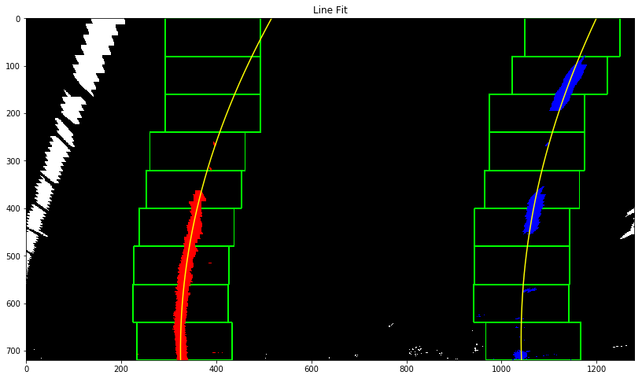

```python
warped_img, M, Minv = PerspectiveTransform(colorAndGradThres, src, dst)
params = line_fit(warped_img)

left_fit = params['left_fit']
right_fit = params['right_fit']
nonzerox = params['nonzerox']
nonzeroy = params['nonzeroy']
out_img = params['out_img']
left_lane_inds = params['left_lane_inds']
right_lane_inds = params['right_lane_inds']

# Generate x and y values for plotting
ploty = np.linspace(0, warped_img.shape[0]-1, warped_img.shape[0] )
left_fitx = left_fit[0]*ploty**2 + left_fit[1]*ploty + left_fit[2]
right_fitx = right_fit[0]*ploty**2 + right_fit[1]*ploty + right_fit[2]

out_img[nonzeroy[left_lane_inds], nonzerox[left_lane_inds]] = [255, 0, 0]
out_img[nonzeroy[right_lane_inds], nonzerox[right_lane_inds]] = [0, 0, 255]
plt.figure(figsize=(15,8))
plt.imshow(out_img)
plt.plot(left_fitx, ploty, color='yellow')
plt.plot(right_fitx, ploty, color='yellow')
plt.title('Line Fit')
```

## Step 7 - Generate the search window

The searh widow helps in avoiding searching the entire binary warped image again for the windows and creates a boundary to search for the next image. This helps in preventing too much deviations from the previous lane boundary

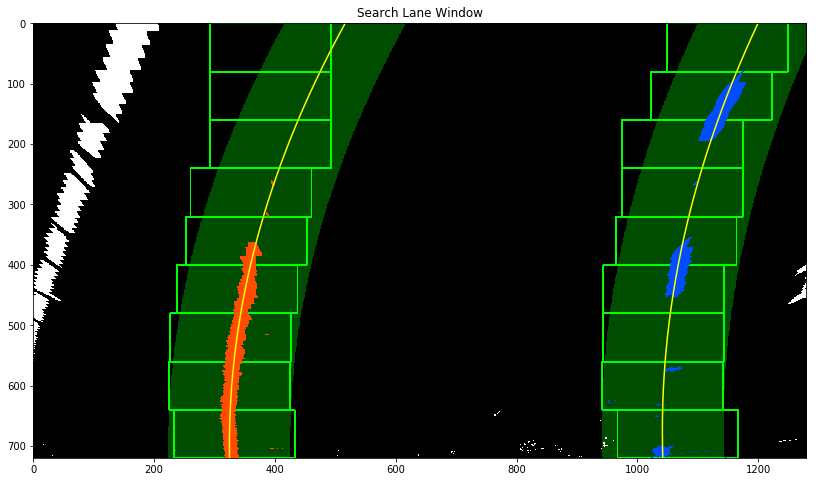

```python
def search_window(params_dict):

    left_fit = params_dict['left_fit']
    right_fit = params_dict['right_fit']
    nonzerox = params_dict['nonzerox']
    nonzeroy = params_dict['nonzeroy']
    out_img = params_dict['out_img']
    left_lane_inds = params_dict['left_lane_inds']
    right_lane_inds = params_dict['right_lane_inds']
    margin = 100

    window_img = np.zeros_like(out_img)
    ploty = np.linspace(0, out_img.shape[0]-1, out_img.shape[0] )
    left_fitx = left_fit[0]*ploty**2 + left_fit[1]*ploty + left_fit[2]
    right_fitx = right_fit[0]*ploty**2 + right_fit[1]*ploty + right_fit[2]

    # Color in left and right line pixels
    out_img[nonzeroy[left_lane_inds], nonzerox[left_lane_inds]] = [255, 0, 0]
    out_img[nonzeroy[right_lane_inds], nonzerox[right_lane_inds]] = [0, 0, 255]

    # Generate a polygon to illustrate the search window area
    # And recast the x and y points into usable format for cv2.fillPoly()
    left_line_window1 = np.array([np.transpose(np.vstack([left_fitx-margin, ploty]))])
    left_line_window2 = np.array([np.flipud(np.transpose(np.vstack([left_fitx+margin,
                                  ploty])))])
    left_line_pts = np.hstack((left_line_window1, left_line_window2))
    right_line_window1 = np.array([np.transpose(np.vstack([right_fitx-margin, ploty]))])
    right_line_window2 = np.array([np.flipud(np.transpose(np.vstack([right_fitx+margin,
                                  ploty])))])
    right_line_pts = np.hstack((right_line_window1, right_line_window2))

    # Draw the lane onto the warped blank image
    cv2.fillPoly(window_img, np.int_([left_line_pts]), (0,255, 0))
    cv2.fillPoly(window_img, np.int_([right_line_pts]), (0,255, 0))
    window_img = cv2.addWeighted(out_img, 1, window_img, 0.3, 0)

    return window_img, ploty, left_fitx, right_fitx

window_img, ploty, left_fitx, right_fitx = search_window(params)
plt.figure(figsize=(15,8))
plt.imshow(window_img)
plt.plot(left_fitx, ploty, color='yellow')
plt.plot(right_fitx, ploty, color='yellow')
plt.title('Search Lane Window')
```

## Estimate the curvature

```python
def calc_curve(left_lane_inds, right_lane_inds, nonzerox, nonzeroy):

    y_eval = 719  # 720p video/image, so last (lowest on screen) y index is 719

    # Define conversions in x and y from pixels space to meters
    ym_per_pix = 30/720 # meters per pixel in y dimension
    xm_per_pix = 3.7/700 # meters per pixel in x dimension

    # Extract left and right line pixel positions
    leftx = nonzerox[left_lane_inds]
    lefty = nonzeroy[left_lane_inds]
    rightx = nonzerox[right_lane_inds]
    righty = nonzeroy[right_lane_inds]

    # Fit new polynomials to x,y in world space
    left_fit_cr = np.polyfit(lefty*ym_per_pix, leftx*xm_per_pix, 2)
    right_fit_cr = np.polyfit(righty*ym_per_pix, rightx*xm_per_pix, 2)
    # Calculate the new radii of curvature
    left_curverad = ((1 + (2*left_fit_cr[0]*y_eval*ym_per_pix + left_fit_cr[1])**2)**1.5) / np.absolute(2*left_fit_cr[0])
    right_curverad = ((1 + (2*right_fit_cr[0]*y_eval*ym_per_pix + right_fit_cr[1])**2)**1.5) / np.absolute(2*right_fit_cr[0])
    # Now our radius of curvature is in meters

    return left_curverad, right_curverad
```

## Estimate vehicle offset from center of the vehicle

```python
def calc_vehicle_offset(undist, left_fit, right_fit):

    # Calculate vehicle center offset in pixels
    bottom_y = undist.shape[0] - 1
    bottom_x_left = left_fit[0]*(bottom_y**2) + left_fit[1]*bottom_y + left_fit[2]
    bottom_x_right = right_fit[0]*(bottom_y**2) + right_fit[1]*bottom_y + right_fit[2]
    vehicle_offset = undist.shape[1]/2 - (bottom_x_left + bottom_x_right)/2

    # Convert pixel offset to meters
    xm_per_pix = 3.7/700 # meters per pixel in x dimension
    vehicle_offset *= xm_per_pix

    return vehicle_offset
```

## Final visulization to draw the detected lane boundary and estimated parameters such as curvature and offset on the image

```python
def final_vizual(undist, left_fit, right_fit, m_inv, left_curve, right_curve, vehicle_offset):

    # Generate x and y values for plotting
    ploty = np.linspace(0, undist.shape[0]-1, undist.shape[0])
    left_fitx = left_fit[0]*ploty**2 + left_fit[1]*ploty + left_fit[2]
    right_fitx = right_fit[0]*ploty**2 + right_fit[1]*ploty + right_fit[2]

    # Create an image to draw the lines on
    #warp_zero = np.zeros_like(warped).astype(np.uint8)
    #color_warp = np.dstack((warp_zero, warp_zero, warp_zero))
    color_warp = np.zeros((720, 1280, 3), dtype='uint8')  # NOTE: Hard-coded image dimensions

    # Recast the x and y points into usable format for cv2.fillPoly()
    pts_left = np.array([np.transpose(np.vstack([left_fitx, ploty]))])
    pts_right = np.array([np.flipud(np.transpose(np.vstack([right_fitx, ploty])))])
    pts = np.hstack((pts_left, pts_right))

    # Draw the lane onto the warped blank image
    cv2.fillPoly(color_warp, np.int_([pts]), (0,255, 0))

    # Warp the blank back to original image space using inverse perspective matrix (Minv)
    newwarp = cv2.warpPerspective(color_warp, m_inv, (undist.shape[1], undist.shape[0]))
    # Combine the result with the original image
    result = cv2.addWeighted(undist, 1, newwarp, 0.3, 0)

    # Annotate lane curvature values and vehicle offset from center
    avg_curve = (left_curve + right_curve)/2
    label_str = 'Radius of curvature: %.1f m' % avg_curve
    font = cv2.FONT_HERSHEY_COMPLEX
    result = cv2.putText(result, label_str, (50,40), 0, 1, (255,0,0), 3, font)

    label_str = 'Vehicle offset from lane center: %.1f m' % vehicle_offset
    result = cv2.putText(result, label_str, (50,90), 0, 1, (255,0,0), 3, font)


    return result
```

## Steps to get the final image

process_image() function implements above steps and also sanity checks and smoothing function for estimation of left and right lanes.

```python
from collections import deque
queue_depth = 10
left_lane_history = deque(maxlen = queue_depth)
right_lane_history = deque(maxlen = queue_depth)
prev_left_lane_fit = deque(maxlen = 1)
prev_right_lane_fit = deque(maxlen = 1)

def process_image(img):

    undist = cv2.undistort(img, mtx, dist, None, mtx)

    colorAndGradThres = combined_thresh(undist)

    warped_img, M, Minv = PerspectiveTransform(colorAndGradThres, src, dst)

    params = line_fit(warped_img)
    left_lane_history.append(params['left_fit'])
    right_lane_history.append(params['right_fit'])

    lane_depth = 0
    mean_left_lane = np.zeros_like(params['left_fit']).astype(np.float)
    mean_right_lane = np.zeros_like(params['right_fit']).astype(np.float)

    for idx in range(len(left_lane_history)):
        left_lane = left_lane_history[idx]
        right_lane = right_lane_history[idx]
        #Sanity Check if a fixed 500 pixels seperation is there between left and right lanes and also both have same direction of bends
        if (((right_lane[2]-left_lane[2]) > 500) & (np.absolute(np.sign(right_lane[0])-np.sign(left_lane[0]))<=1)):
            mean_left_lane = mean_left_lane + left_lane
            mean_right_lane = mean_right_lane + right_lane
            if np.all(left_lane != 0):
                lane_depth += 1
    if lane_depth>=1:
        mean_left_lane /= lane_depth
        mean_right_lane /= lane_depth
    else:
        mean_left_lane = prev_left_lane_fit[0]
        mean_right_lane = prev_right_lane_fit[0]


    left_curve, right_curve = calc_curve(params['left_lane_inds'], params['right_lane_inds'], params['nonzerox'], params['nonzeroy'])
    # Sanity Check, else fall back to earlier good lane estimate
    if ((np.absolute(left_curve-right_curve)>1000) | ((left_curve+right_curve)/2 >= 2000)):
        mean_left_lane = prev_left_lane_fit[0]
        mean_right_lane = prev_right_lane_fit[0]

    vehicle_offset = calc_vehicle_offset(img, mean_left_lane, mean_right_lane)

    #result_img = final_vizual(undist, params['left_fit'], params['right_fit'], Minv, left_curve, right_curve, vehicle_offset)
    result_img = final_vizual(undist, mean_left_lane, mean_right_lane, Minv, left_curve, right_curve, vehicle_offset)
    prev_left_lane_fit.append(mean_left_lane)
    prev_right_lane_fit.append(mean_right_lane)

    return result_img
```

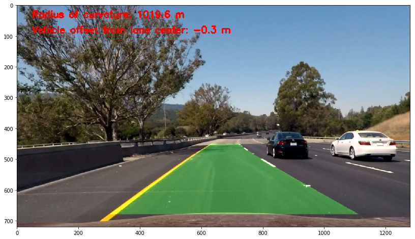

```python
img = plt.imread('test_images/test6.jpg')

result_img = process_image(img)
plt.figure(figsize=(15,8))
plt.imshow(result_img)
```

## Run only for the test images to be populated in the test_images folder

[figure not shown]

```python
if GENERATE_OUT_FIGURES==True:
    image_files = os.listdir('test_images')
    for image_file in image_files:
        img = plt.imread('test_images/' + image_file)
        out_image_file = image_file.split('.')[0] + '.jpg'

        mtx, dist = CameraCalibration()
        undist = cv2.undistort(img, mtx, dist, None, mtx)
        plt.imshow(undist)
        plt.savefig('output_images/undistort_' + out_image_file)

        colorAndGradThres = combined_thresh(undist)
        plt.imshow(colorAndGradThres, cmap="gray")
        plt.savefig('output_images/thresholded_' + out_image_file)

        warped_img, M, Minv = PerspectiveTransform(colorAndGradThres, src, dst)
        plt.imshow(warped_img, cmap="gray")
        plt.savefig('output_images/warped_' + out_image_file)

        params = line_fit(warped_img)
        left_fit = params['left_fit']
        right_fit = params['right_fit']
        nonzerox = params['nonzerox']
        nonzeroy = params['nonzeroy']
        out_img = params['out_img']
        left_lane_inds = params['left_lane_inds']
        right_lane_inds = params['right_lane_inds']

        # Generate x and y values for plotting
        ploty = np.linspace(0, warped_img.shape[0]-1, warped_img.shape[0] )
        left_fitx = left_fit[0]*ploty**2 + left_fit[1]*ploty + left_fit[2]
        right_fitx = right_fit[0]*ploty**2 + right_fit[1]*ploty + right_fit[2]

        out_img[nonzeroy[left_lane_inds], nonzerox[left_lane_inds]] = [255, 0, 0]
        out_img[nonzeroy[right_lane_inds], nonzerox[right_lane_inds]] = [0, 0, 255]
        plt.imshow(out_img)
        plt.plot(left_fitx, ploty, color='yellow')
        plt.plot(right_fitx, ploty, color='yellow')
        plt.savefig('output_images/color_fit_line_' + out_image_file)
        plt.gcf().clear()

        window_img, ploty, left_fitx, right_fitx = search_window(params)
        plt.imshow(window_img)
        plt.plot(left_fitx, ploty, color='yellow')
        plt.plot(right_fitx, ploty, color='yellow')
        plt.savefig('output_images/search_window_' + out_image_file)
        plt.gcf().clear()

        left_curve, right_curve = calc_curve(params['left_lane_inds'], params['right_lane_inds'], params['nonzerox'], params['nonzeroy'])
        vehicle_offset = calc_vehicle_offset(img, params['left_fit'], params['right_fit'])
        result_img = final_vizual(img, params['left_fit'], params['right_fit'], Minv, left_curve, right_curve, vehicle_offset)
        plt.imshow(result_img)
        plt.savefig('output_images/example_output_' + out_image_file)
```

```python
video_output = "output_images/test_video_output.mp4"
clip1 = VideoFileClip("test_video.mp4")
clip1_output = clip1.fl_image(process_image) #NOTE: this function expects color images!!
%time clip1_output.write_videofile(video_output, audio=False)
```

```
[MoviePy] >>>> Building video output_images/test_video_output.mp4
[MoviePy] Writing video output_images/test_video_output.mp4
```

```
[MoviePy] Done.
[MoviePy] >>>> Video ready: output_images/test_video_output.mp4

Wall time: 21.3 s
```

```python
HTML("""
<video width="900" height="540" controls>
  <source src="{0}">
</video>
""".format(video_output))
```

[video not shown]

```python
video_output = "output_images/project_video_output.mp4"
clip1 = VideoFileClip("project_video.mp4")
clip1_output = clip1.fl_image(process_image) #NOTE: this function expects color images!!
%time clip1_output.write_videofile(video_output, audio=False)
```

```
[MoviePy] >>>> Building video output_images/project_video_output.mp4
[MoviePy] Writing video output_images/project_video_output.mp4
```

```
[MoviePy] Done.
[MoviePy] >>>> Video ready: output_images/project_video_output.mp4

Wall time: 11min 9s
```

```python
HTML("""
<video width="900" height="540" controls>
  <source src="{0}">
</video>
""".format(video_output))
```

[video not shown]

```python
src = np.float32([[270,680], [590,465], [690,465], [1050,680]])
dst = np.float32([[300, 720], [300, 0], [1000,0], [1000,720]])
queue_depth = 8
left_lane_history = deque(maxlen = queue_depth)
right_lane_history = deque(maxlen = queue_depth)

video_output = "output_images/harder_challenge_video_output.mp4"
clip1 = VideoFileClip("harder_challenge_video.mp4")
clip1_output = clip1.fl_image(process_image) #NOTE: this function expects color images!!
%time clip1_output.write_videofile(video_output, audio=False)
```

```
[MoviePy] >>>> Building video output_images/harder_challenge_video_output.mp4
[MoviePy] Writing video output_images/harder_challenge_video_output.mp4
```

```
[MoviePy] Done.
[MoviePy] >>>> Video ready: output_images/harder_challenge_video_output.mp4

Wall time: 11min 17s
```

```python
HTML("""
<video width="900" height="540" controls>
  <source src="{0}">
</video>
""".format(video_output))
```

[video not shown]